# Course 5 Week 2 Assignment

Nic Neo

8 July 2020

## 1. Loading and preprocessing the data

```r
#Load packages
library(dplyr)
```

```r
library(ggplot2)
# Get Data from the web
UrlFile <- "https://d396qusza40orc.cloudfront.net/repdata%2Fdata%2Factivity.zip"
filename <- "activity.zip"
if (!file.exists(filename)) {
  download.file(UrlFile, filename, method = "curl")
}
dataset.name <- "activity.csv"
if (!file.exists(dataset.name)) {
  unzip(filename)
}
# Read data
activitydata <- read.csv(dataset.name, header = TRUE)
# Convert date variable into data class
activitydata$date <- as.Date(activitydata$date, format = "%Y-%m-%d")
```

## 2. What is the mean total number of steps taken per day?

2.1. Calculate the total number of steps taken per day

```r
total.steps <- activitydata %>%
  group_by(date) %>%
  summarize(sum(steps))
colnames(total.steps) = c("date", "steps")
```

2.2. Create histogram of total number of steps taken each day

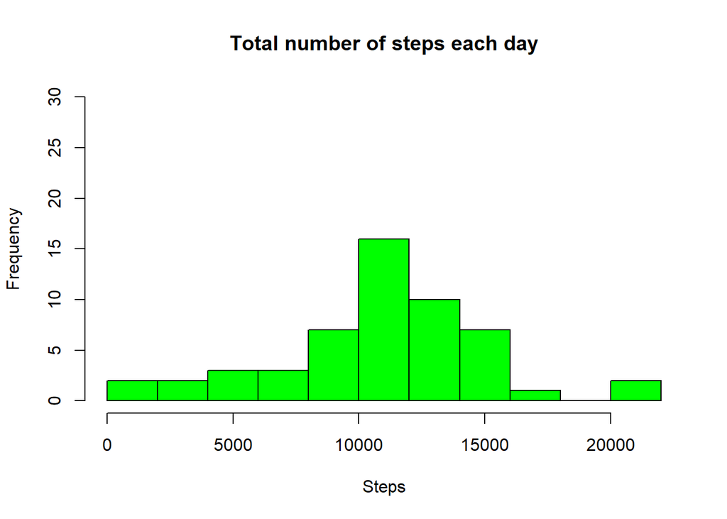

```r
hist(total.steps$steps,
     breaks = 10,
     xlab = "Steps",
     main = "Total number of steps each day",
     ylim = range(0, 30),
     col = "green")
```

2.3. Calculate and report the mean and median of the total number of steps taken per day

```r
# Mean total number of steps taken per day
mean.steps <- as.integer(mean(total.steps$steps, na.rm = TRUE))
# Median total number of steps taken per day
median.steps <- as.integer(median(total.steps$steps, na.rm = TRUE))
```

**The mean and median number of steps taken per day is 10766 and 10765 respectively.**

## 3. What is the average daily activity pattern?

3.1. Make a time series plot (i.e. type = “l”) of the 5-minute interval (x-axis) and the average number of steps taken, averaged across all days (y-axis)

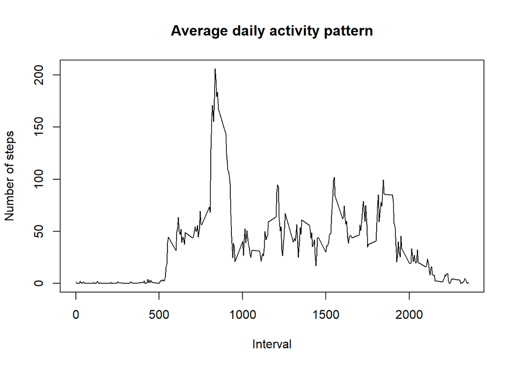

```r
# Get the average number of steps taken across all days
stepsbyinterval <- activitydata %>%
  group_by(interval) %>%
  summarize(mean(steps, na.rm = TRUE))
colnames(stepsbyinterval) = c("interval", "steps")
# Plot the intervals of the average steps
plot(stepsbyinterval$interval,
     as.numeric(stepsbyinterval$steps),
     type = "l",
     main = "Average daily activity pattern",
     xlab = "Interval",
     ylab = "Number of steps"
     )
```

3.2. Which 5-minute interval, on average across all the days in the dataset, contains the maximum number of steps?

```r
max.steps <- max(stepsbyinterval$steps)
max.interval <- stepsbyinterval[stepsbyinterval$steps==max.steps, 1]
```

**The maximum number of steps is 206.1698113, at interval 835.**

## 4. Imputing missing values

4.1. Calculate and report the total number of missing values in the dataset (i.e. the total number of rows with NAs).

```r
NA.sum <- sum(is.na(activitydata$steps))
```

**Number of rows with missing values: 2304**

4.2. Devise a strategy for filling in all of the missing values in the dataset. The strategy does not need to be sophisticated. For example, you could use the mean/median for that day, or the mean for that 5-minute interval, etc.

**For that 5-minute interval, fill in the NAs with the mean across all days.**

4.3. Create a new dataset that is equal to the original dataset but with the missing data filled in.

```r
# Merge original activity dataset with mean steps per interval
activitydataFilled <- merge(activitydata, stepsbyinterval, by = "interval", suffixes = c(".original", ".mean"))
# Find rows with NAs
NArows <- which(is.na(activitydataFilled$steps.original))
# Replace NAs with mean
activitydataFilled[NArows, "steps.original"] = activitydataFilled[NArows, "steps.mean"]
# Drop unwanted columns and rename the reamining ones, then round values to 3 sig fig.
activitydataFilled <- activitydataFilled[,1:3]
colnames(activitydataFilled) <- c("interval", "steps", "date")
activitydataFilled$steps <- signif(activitydataFilled$steps, digits = 3)
```

4.4. Make a histogram of the total number of steps taken each day and calculate and report the mean and median total number of steps taken per day. Do these values differ from the estimates from the first part of the assignment? What is the impact of imputing missing data on the estimates of the total daily number of steps?

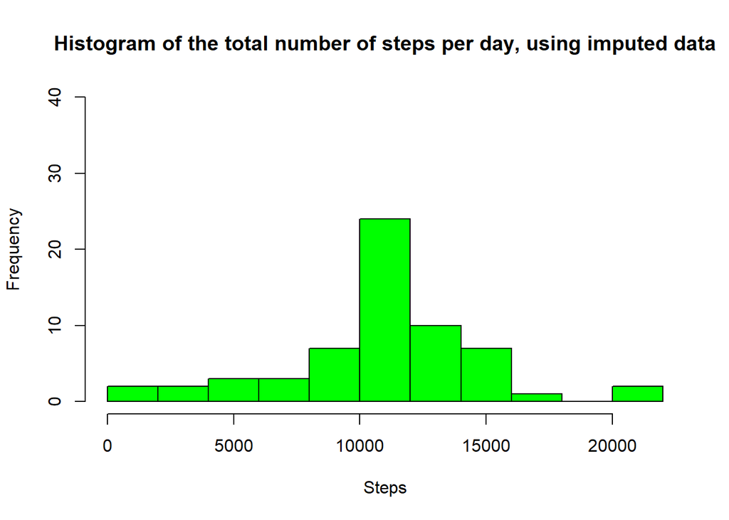

```r
# Calculate total number of steps taken per day
total.steps2 <- activitydataFilled %>%
  group_by(date) %>%
  summarize(sum(steps))
colnames(total.steps2) = c("date", "steps")
# Create histogram of total number of steps taken each day
hist(total.steps2$steps,
     breaks = 10,
     xlab = "Steps",
     main = "Histogram of the total number of steps per day, using imputed data",
     ylim = range(0, 40),
     col = "green")
```

```r
# Obtain mean and median steps per day, report difference from original data
# Mean total number of steps taken per day
mean.steps2 <- as.integer(mean(total.steps2$steps, na.rm = TRUE))
# Median total number of steps taken per day
median.steps2 <- as.integer(median(total.steps2$steps, na.rm = TRUE))
```

**New mean number of steps taken per day –> 10766** **COMPARED to** **Original mean –> 10766**

**New median number of steps taken per day –> 10764** **COMPARED to** **Original median –> 10765**

## 5. Are there differences in activity patterns between weekdays and weekends?

For this part the weekdays() function may be of some help here. Use the dataset with the filled-in missing values for this part.

5.1. Create a new factor variable in the dataset with two levels – “weekday” and “weekend” indicating whether a given date is a weekday or weekend day.

```r
# New factor variable column
activitydataFilled$day <- ifelse(weekdays(as.Date(activitydataFilled$date)) == "Saturday" | weekdays(as.Date(activitydataFilled$date)) == "Sunday", "weekend", "weekday")
```

5.2. Make a panel plot containing a time series plot (i.e. type=“l”) of the 5-minute interval (x-axis) and the average number of steps taken, averaged across all weekday days or weekend days (y-axis).

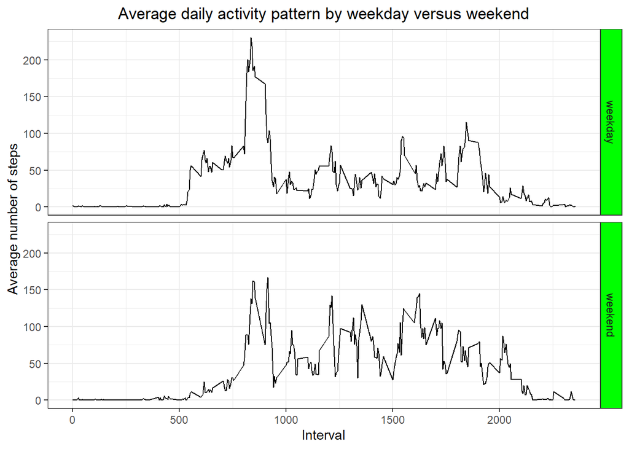

```r
# Average number of steps taken across all weekdays or weekend days
stepsbyday <- activitydataFilled %>%
  group_by(interval, day) %>%
  summarize(mean(steps, na.rm = TRUE))
colnames(stepsbyday) = c("interval", "day", "steps")
# Panel plot
ggplot(stepsbyday, aes(interval, steps)) +
  geom_line() +
  facet_grid(day ~ .) +
  labs(x = "Interval",
       y = "Average number of steps") +
    ggtitle("Average daily activity pattern by weekday versus weekend") +
    theme_bw() +
    theme(plot.title = element_text(hjust = 0.5)) +
    theme(strip.background = element_rect(fill = "green"))
```